# Домашнее задание

### МОВС. 2025-2026

### Анализ временных рядов

**Выдано:** 02.12.2025

**Срок сдачи:** 16.12.2025 23:59 MSK

```
Обратите внимание, что если у ассистента возникают подозрения по честному выполнению заданий (плагиат или использование LLM без указания промпта), то он может поставить вам устное собеседование по проделанной работе, по итогам которого он вправе обнулить вам работу.
```

В общем, когда вы читерите, то заставляете в мире плакать одного котенка и одного ассистента. Пожалейте их.

[figure not shown]

А теперь после такой грозной ноты — к более приятному.

Мы постарались составить домашнее задание так, чтобы оно помогло закрепить все то, что мы прошли на первых занятиях, посвященных классическим методам прогнозирования временных рядов. А также узнать пару новых сюжетов.

Сейчас мы будем работать со сгенерированным временным рядом, истинную форму которого вы не знаете, а мы знаем. Это все равно не значит, что мы будем знать, как построить идеальную модель (потому что в ряде есть артефакты, которые ни ETS-модель, ни SARIMA-модель не смогут до конца хорошо учесть), но мы сможем примерно оценить, а те ли компоненты и свойства ряда вы смогли примерно найти.

В бонусной части вы сможете поработать с реальным рядом и понять, насколько это больнее (а может и нет) :)

Также парочка бонусов будет раскидана по заданиям в основной части. Без бонусов можно набрать максимум 10 баллов, с бонусами — 15. При этом бонусы в сумме дают больше 5 баллов — вы можете выбирать, какие из них делать, а какие нет.

```python
import random
from typing import Any

import numpy as np
import pandas as pd
import matplotlib.pyplot as plt



from statsmodels.graphics.tsaplots import plot_acf, plot_pacf
from statsmodels.tsa.seasonal import STL
from statsmodels.tsa.stattools import adfuller, kpss
from statsmodels.tsa.api import Holt, SimpleExpSmoothing
from statsmodels.tsa.exponential_smoothing.ets import ETSModel
from statsmodels.tsa.statespace.sarimax import SARIMAX


from sklearn.metrics import mean_absolute_error


from statsforecast.models import AutoETS, AutoARIMA, Theta
from statsforecast import StatsForecast


from prophet import Prophet
import logging
# Prophet очень болтливый, глушим логи
logging.getLogger('cmdstanpy').setLevel(logging.WARNING)
```

```
Importing plotly failed. Interactive plots will not work.
```

```python
def seed_everything(seed=42):
    random.seed(seed)
    np.random.seed(seed)


seed_everything()
```

### Задание 1. Первичный анализ данных (1 балл)

Для оценки качества прогнозирования будем использовать метрики MAE и MASE.

`Ответьте на вопрос (0.1 балл):` Что показывает метрика MASE и в чем ее отличие от просто MAE? В каких случаях ее использование предпочтительнее?

Мы уже с вами имплементировали метрики на одном из занятий, так что давайте просто их заберем оттуда.

```python
def mase(
    forecast: np.ndarray,
    insample: np.ndarray,
    outsample: np.ndarray,
    frequency: int,
) -> np.ndarray:
    """MASE loss as defined in "Scaled Errors" https://robjhyndman.com/papers/mase.pdf

    Args:
        forecast: Forecast values. Shape: batch, time_o
        insample: Insample values. Shape: batch, time_i
        outsample: Target values. Shape: batch, time_o
        frequency: Frequency value
    Returns:
        Same shape array with error calculated for each time step
    """
    return np.mean(np.abs(forecast - outsample)) / np.mean(
        np.abs(insample[:-frequency] - insample[frequency:])
    )
```

Метрика показывает MASE среднюю абсолютную ошибку модели, нормированную (масштабированную) на среднюю ошибку наивного прогноза на обучающей выборке . Значение меньше 1 означает, что модель точнее наивного подхода.

Отличие от MAE: MAE является абсолютной метрикой и зависит от масштаба (единиц измерения) данных. MASE — безразмерная (относительная) величина, не зависящая от порядка значений ряда.

Когда предпочтительнее: При сравнении качества моделей на множестве различный временных рядов, которые имеют разные единицы измерения или сильно отличающиеся масштабы значений.

#### Задание 1.1: Загрузка данных (0 баллов)

Подгрузите данные из файла `synthetic_ts.csv`.

```python
df = pd.read_csv('synthetic_ts.csv')
df.head(3)
```

|  | date | y |
| --- | --- | --- |
| 0 | 2000-01-31 | 10.000000 |
| 1 | 2000-02-29 | 9.709006 |
| 2 | 2000-03-31 | 13.652092 |

#### Задание 1.2: Типы данных (0.05 балла)

Выведите типы данных в датасете. Проверьте, что они корректные: даты должны быть в формате datetime, а значения — float. Если это не так, то исправьте их.

```python
df.info()
```

```
<class 'pandas.core.frame.DataFrame'>
RangeIndex: 300 entries, 0 to 299
Data columns (total 2 columns):
 #   Column  Non-Null Count  Dtype
---  ------  --------------  -----
 0   date    300 non-null    object
 1   y       300 non-null    float64
dtypes: float64(1), object(1)
memory usage: 4.8+ KB
```

```python
df['date'] = pd.to_datetime(df['date'])
df.info()
```

```
<class 'pandas.core.frame.DataFrame'>
RangeIndex: 300 entries, 0 to 299
Data columns (total 2 columns):
 #   Column  Non-Null Count  Dtype
---  ------  --------------  -----
 0   date    300 non-null    datetime64[ns]
 1   y       300 non-null    float64
dtypes: datetime64[ns](1), float64(1)
memory usage: 4.8 KB
```

#### Задание 1.3: Пропуски (0.05 балла)

Проверьте, есть ли в данных пропуски. Если они есть, то заполните их предыдущими значениями. Если пропусков нет, то просто выведите сообщение об этом.

```python
if df.isna().sum().sum() > 0:
    print("В данных есть пропуски")
    df = df.ffill()
else:
    print("Пропусков нет")
```

```
Пропусков нет
```

#### Задание 1.4: Визуальный анализ временных рядов (0.7 балла)

Постройте линейные графики временного ряда. По оси X отложите время, по оси Y — значения временного ряда.

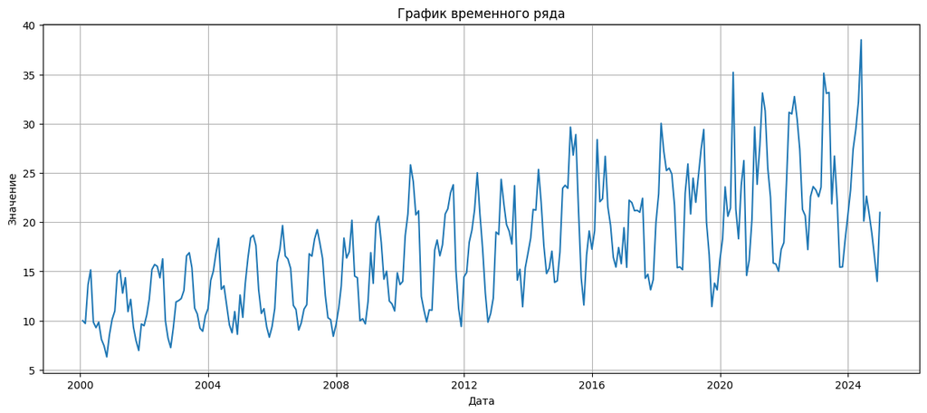

```python
def plot_ts(date, y, title = 'График временного ряда'):
    plt.figure(figsize=(15, 6))
    plt.plot(date, y)
    plt.title(title)
    plt.xlabel('Дата')
    plt.ylabel('Значение')
    plt.grid(True)
    plt.show()

plot_ts(df['date'], df['y'])
```

`Ответьте на следующие вопросы:`

- Какова частотность (frequency) данных?
- Стационарен ли временной ряд? Если нет, то какие признаки нестационарности вы можете выделить?
- Месячная частотность, данные идут с шагом в один месяц.
- Ряд не стационарен.

Признаки нестационарности:

- Тренд: Виден явный рост среднего значения со временем.
- Сезонность: Присутствуют четкие повторяющиеся циклы.
- Гетероскедастичность: Амплитуда колебаний (разброс) увеличивается по мере роста уровня ряда (график становится "шире" к концу).

Теперь постройте графики [автокорреляций (ACF)](https://www.statsmodels.org/dev/generated/statsmodels.graphics.tsaplots.plot_acf.html) и [частных автокорреляций (PACF)](https://www.statsmodels.org/dev/generated/statsmodels.graphics.tsaplots.plot_pacf.html) до 40-го лага для тренировочной выборки.

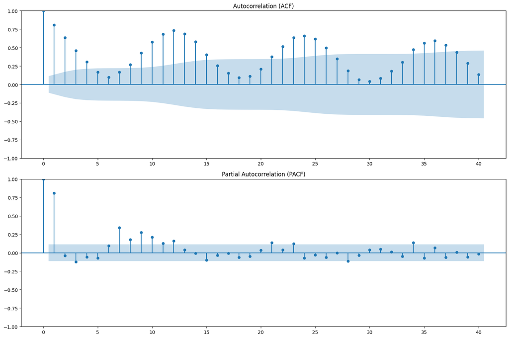

```python
fig, ax = plt.subplots(2, 1, figsize=(15, 10))

plot_acf(df['y'], lags=40, ax=ax[0])
ax[0].set_title('Autocorrelation (ACF)')

plot_pacf(df['y'], lags=40, ax=ax[1], method='ywm')
ax[1].set_title('Partial Autocorrelation (PACF)')

plt.tight_layout()
plt.show();
```

`Ответьте на следующие вопросы:`

- Стационарен ли временной ряд?
- Присутствует ли в нём тренд? Сезонность? Цикличность?
- Если ряд сезонный, то какой период выглядит наиболее вероятным? Можем ли мы сказать, что сезонность аддитивная? Мультипликативная?
- Нет, ряд не стационарен. График ACF убывает очень медленно, что является классическим признаком нестационарности (наличия тренда).
- Присутствует явный тренд (медленное затухание ACF) и сильная сезонность (отчетливые "волны" на графике ACF).
- Наиболее вероятный период — **12** (пики корреляции видны на лагах 12, 24, 36). Сезонность **мультипликативная**, так как на исходном графике ряда амплитуда колебаний увеличивалась вместе с ростом значений.

#### Задание 1.5: Выделение тестовой выборки (0.1 балл)

Выделите 10% данных для теста, а остальные 90% оставьте для обучения.

`Ответьте на вопрос:` В чем особенность выделения тестовой выборки в задаче прогнозирования временных рядов?

```python
split_idx = int(len(df) * 0.9)
train = df.iloc[:split_idx]
test = df.iloc[split_idx:]
```

> Главная особенность — запрет на перемешивание (shuffle). Данные должны разделяться строго хронологически: более ранние наблюдения идут в обучение, а более поздние — в тест. Случайное перемешивание приведет к «подглядыванию в будущее» (data leakage) и некорректной оценке модели.

### Задание 2. Стабилизация дисперсии временного ряда (2 балла + 1 бонусный балл)

На одном из занятий мы с вами обсуждали, что для стабилизации дисперсии временного ряда можно использовать преобразование Box-Cox. Давайте разберемся как оно работает. Помним, что Box-Cox нельзя использовать для отрицательных значений, но у нас их и нет.

#### Задание 2.1: Имплементация Box-Cox (1 балл)

Реализуйте прямую и обратную трансформацию Box-Cox (пользоваться готовым решением нельзя!).

Прямое преобразование Box–Cox:

$$ z = g(y;\lambda) = \begin{cases} \dfrac{y^{\lambda} - 1}{\lambda}, & \lambda \ne 0, \\[6pt] \log y, & \lambda = 0. \end{cases} $$

Обратное преобразование Box–Cox:

$$ y = g^{-1}(z;\lambda) = \begin{cases} (\lambda z + 1)^{1/\lambda}, & \lambda \ne 0, \\[6pt] e^{z}, & \lambda = 0. \end{cases} $$

`БОНУС (1 балл):` Выведите формулы для обратного преобразования Box-Cox. Можно прикрепить к домашнему заданию файл с решением. Или сюда фотку. Или же ЗаТеХаТь.

**Случай 1: $\lambda \neq 0$**

Выразим $y$ из уравнения $z = \frac{y^{\lambda} - 1}{\lambda}$:

1. Умножим обе части на $\lambda$: $$ \lambda z = y^{\lambda} - 1 $$
2. Перенесем единицу влево: $$ \lambda z + 1 = y^{\lambda} $$
3. Возведем обе части в степень $1/\lambda$: $$ y = (\lambda z + 1)^{1/\lambda} $$

**Случай 2: $\lambda = 0$**

Выразим $y$ из уравнения $z = \ln y$:

1. Применим экспоненту к обеим частям: $$ e^z = e^{\ln y} $$
2. Получим результат: $$ y = e^z $$

```python
def box_cox(x: np.ndarray, lam: float) -> np.ndarray:
    if np.isclose(lam, 0):
        return np.log(x)
    return (np.power(x, lam) - 1) / lam

def inv_box_cox(y: np.ndarray, lam: float) -> np.ndarray:
    if np.isclose(lam, 0):
        return np.exp(y)
    return np.power(y * lam + 1, 1 / lam)
```

Проверьте, что `(inv_box_cox(box_cox(x, lam), lam))` примерно восстанавливает исходный массив x.

```python
# Проверка
x_check = np.array([1.0, 5.0, 10.0, 20.0])
lam_check = 0.5
rec_x = inv_box_cox(box_cox(x_check, lam_check), lam_check)

print(f"Original: {x_check}")
print(f"Restored: {rec_x}")
print(f"Difference almost zero: {np.allclose(x_check, rec_x)}")
```

```
Original: [ 1.  5. 10. 20.]
Restored: [ 1.  5. 10. 20.]
Difference almost zero: True
```

#### Задание 2.2: Подбор параметра λ (1 балл)

Перебор параметры $\lambda$ в боевых условиях происходит с помощью максимизации логарифма правдоподобия ([The optimal lambda parameter for minimizing skewness is estimated on each feature independently using maximum likelihood](https://scikit-learn.org/stable/modules/generated/sklearn.preprocessing.PowerTransformer.html)).

Но давайте пойдем более простым путем: переберите 3-4 значения $\lambda$ в диапазоне от -2 до 2. Постройте графики полученных рядов и визуально оцените, при каком $\lambda$ дисперсия выглядит наиболее стабильной.

Переберите еще несколько значений $\lambda$ рядом с тем, которое показалось вам лучшим.

`Ответьте на вопрос:` Как $\lambda$ влияет на вид преобразованного ряда?

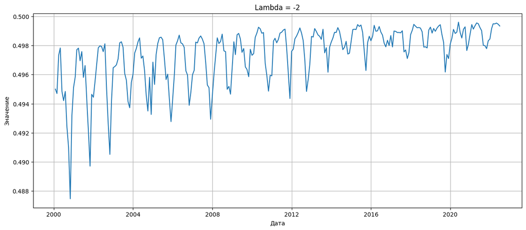

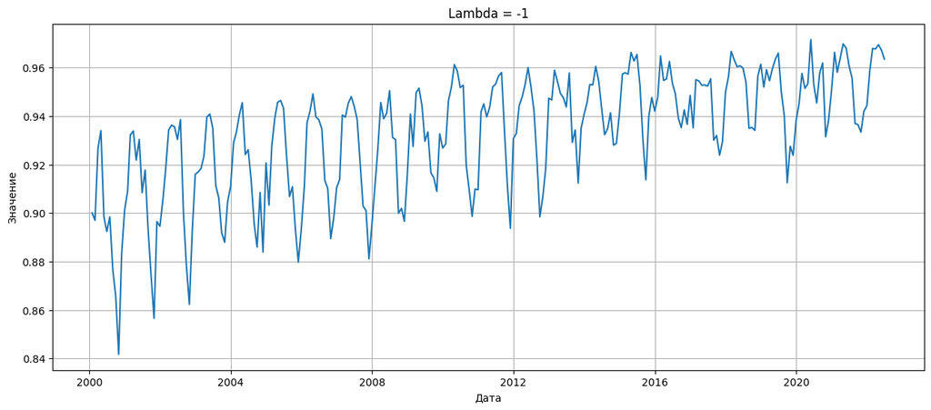

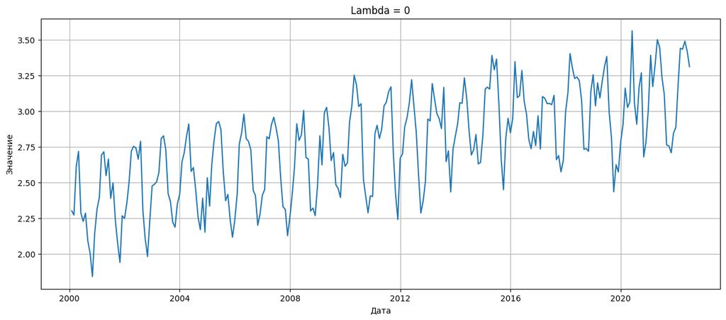

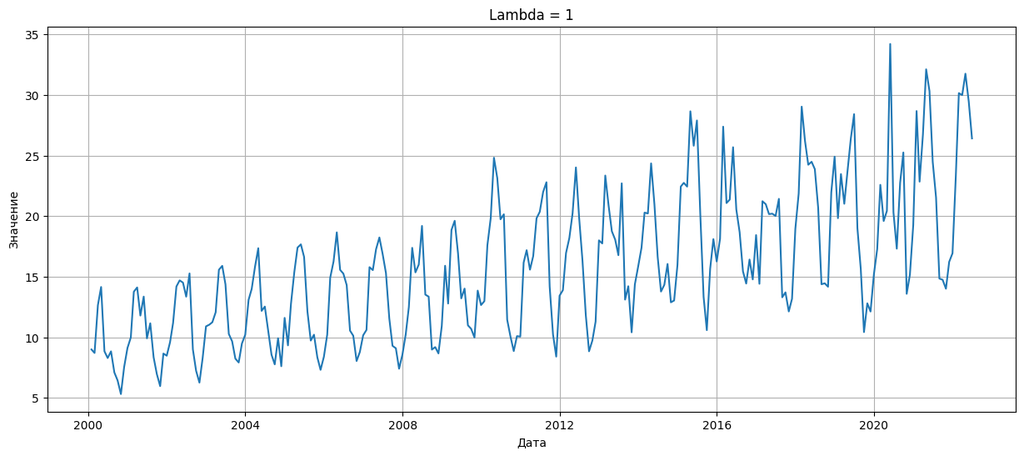

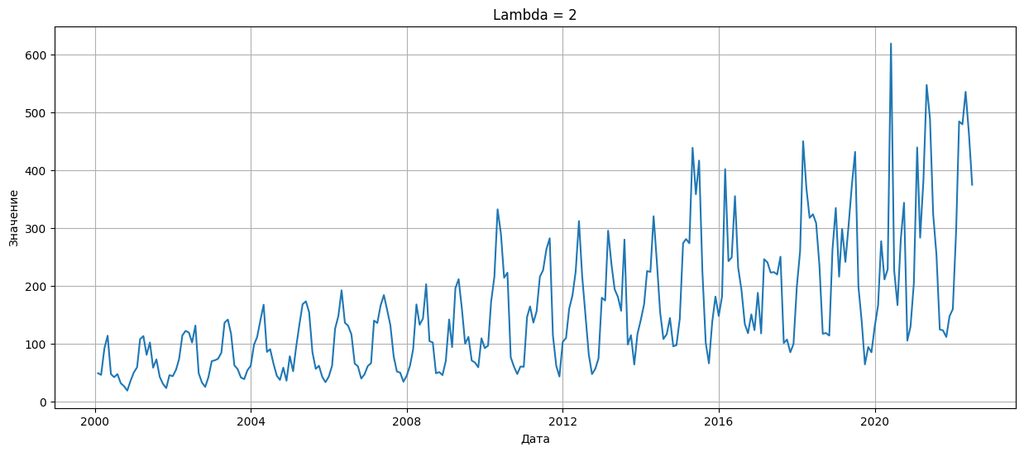

```python
lambdas = [-2, -1, 0, 1, 2]

for l  in lambdas:
    y_transformed = box_cox(train['y'].values, l)
    plot_ts(train['date'], y_transformed, title=f'Lambda = {l}')
```

Наиболее стабильно ряд вышлядит при $\lambda = 0$ Переберём значения рядом с 0

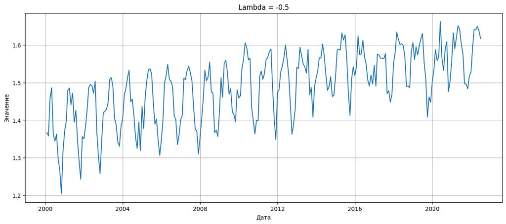

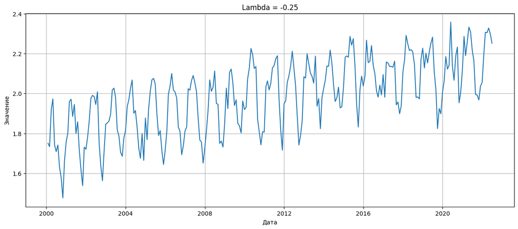

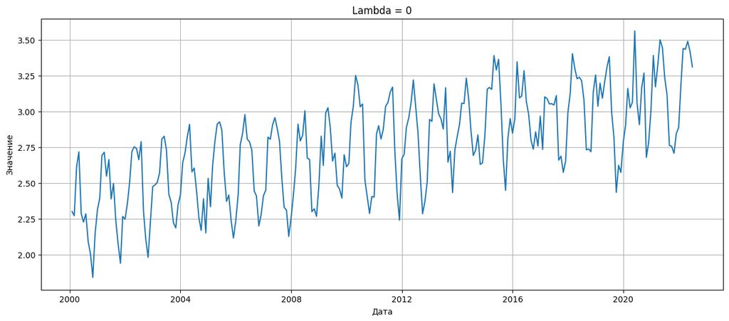

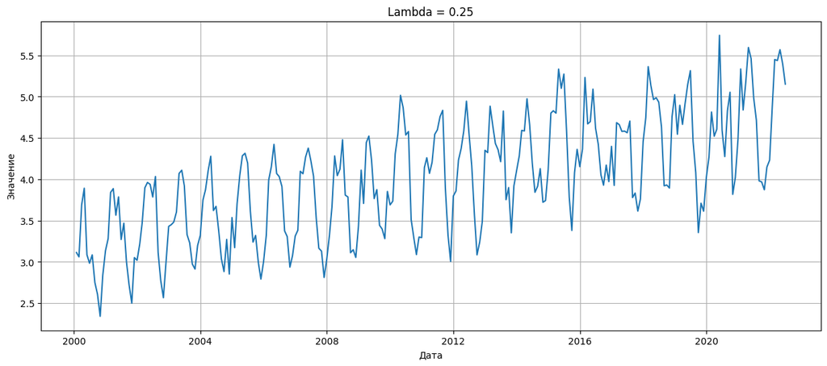

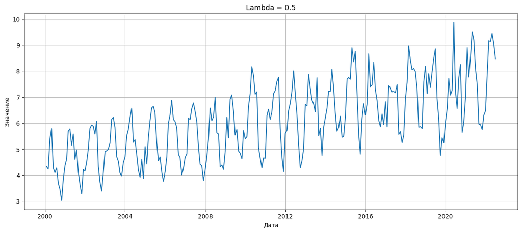

```python
lambdas = [-0.5, -0.25, 0, 0.25, 0.5]

for l  in lambdas:
    y_transformed = box_cox(train['y'].values, l)
    plot_ts(train['date'], y_transformed, title=f'Lambda = {l}')
```

Кажется, лучше всего сжат ряд при $\lambda = -0.5$

Параметр $\lambda$ определяет силу "сжатия" данных:

- **$\lambda = 1$**: данные не меняются (линейно смещаются на -1).
- **$\lambda < 1$**: чем меньше $\lambda$, тем сильнее сжимаются большие значения ряда ("пики") относительно маленьких. Это позволяет выровнять дисперсию, если она растет вместе с уровнем ряда. $\lambda=0$ соответствует логарифмированию (сильное сжатие), отрицательные $\lambda$ — ещё более сильному сжатию (гиперболическое преобразование).
- **$\lambda > 1$**: наоборот, растягивает большие значения, увеличивая дисперсию .

`Бонус (1 балл):` Предложите и реализуйте автоматический подбор параметра $\lambda$ (не обязательно с помощью максимизации логарифма правдоподобия). Для получения полного балла оно должно показать результат не хуже подобранной $\lambda$ на глаз.

Сохраните для последующих заданий и исходный ряд, и преобразованный рядом с оптимальным $\lambda$.

**Суть метода:** Подход базируется на стабилизации дисперсии путем устранения корреляции между уровнем ряда и амплитудой его колебаний. У исходных нестационарных данных, как правило, наблюдается гетероскедастичность (разброс растет вместе со средним значением).

**Алгоритм реализации:**

1. Осуществляется перебор значений параметра $\lambda$ в заданном диапазоне .
2. Для каждого значения $\lambda$ производится трансформация ряда.
3. Для каждого трансформированного ряда вычисляются **скользящее среднее** (характеризует тренд) и **скользящее стандартное отклонение** (характеризует разброс) с окном, равным периоду сезонности.
4. В качестве оптимального выбирается значение $\lambda$, при котором модуль коэффициента корреляции между скользящим средним и скользящим отклонением **минимален** (близок к нулю). Это гарантирует, что ширина колебаний графика становится постоянной и не зависит от его высоты.

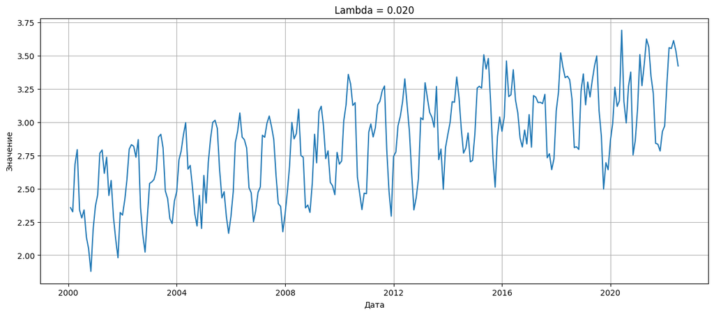

```python
lambdas = np.linspace(-2, 2, 100)
best_lam = None
min_corr = float('inf')
window_size = 12 # берем 12, т.к.  сезонность  годовая

for lam in lambdas:
    y_trans = box_cox(train['y'].values, lam)

    # Делаем из этого серию для удобства расчета скользящих метрик
    s_trans = pd.Series(y_trans)

    # Считаем скользящее среднее и стд. отклонение
    rol_mean = s_trans.rolling(window_size).mean()
    rol_std = s_trans.rolling(window_size).std()

    # Считаем корреляцию Пирсона между уровнем и шумом
    # Нас интересует модуль корреляции (чем ближе к 0, тем лучше)
    corr = np.abs(rol_mean.corr(rol_std))

    if corr < min_corr:
        min_corr = corr
        best_lam = lam

# Проверка результата
y_smart = box_cox(train['y'].values, best_lam)
plot_ts(train['date'], y_smart, title=f'Lambda = {best_lam:.3f}')
```

Вроде выглядит хорошо - точно не хуже подобранной $\lambda$ на глаз.

### Задание 3. STL + простые модели (1.5 балла)

#### Задание 3.1: STL-декомпозиция (0.5 балла)

Примените STL-декомпозицию к преобразованному ряду, чтобы выделить тренд, сезонность и остатки (здесь можно воспользоваться [готовым методом](https://www.statsmodels.org/dev/examples/notebooks/generated/stl_decomposition.html)).

Постройте графики для каждого из выделенных компонентов.

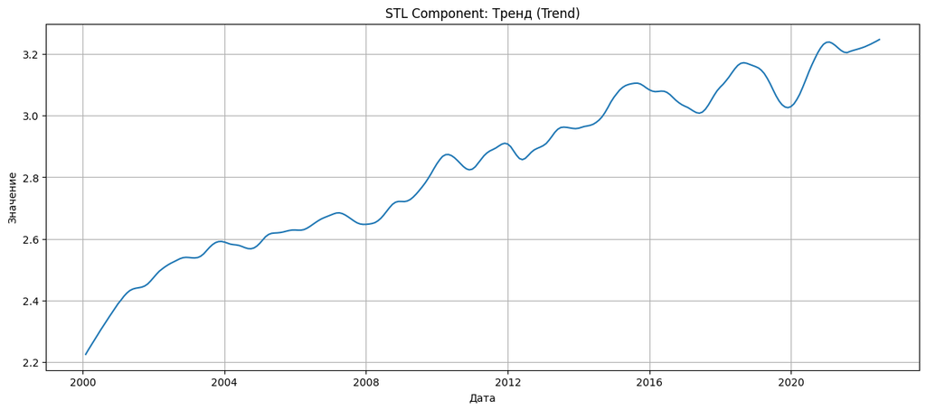

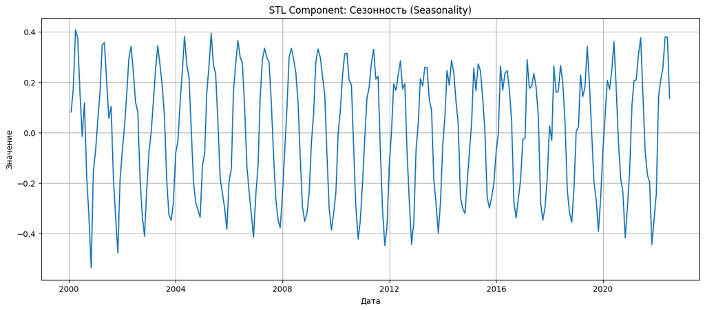

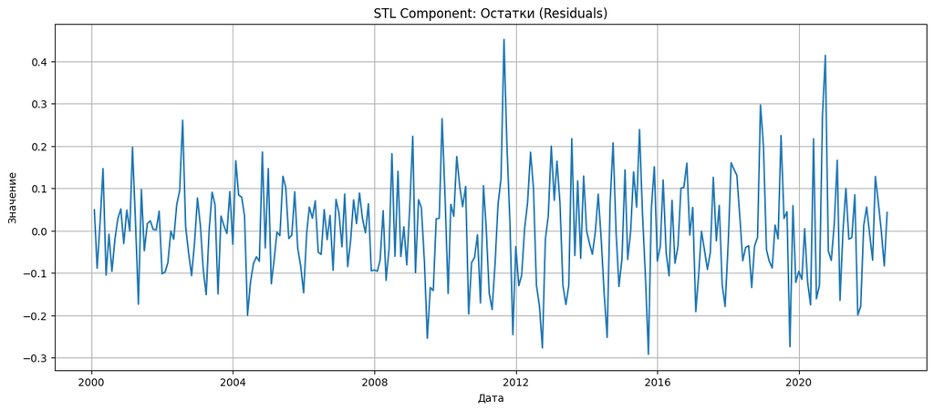

```python
# Создаем pandas Series с правильным индексом даты для удобства STL
ts_series = pd.Series(y_smart, index=train['date'])

# period=12, так как данные месячные
stl = STL(ts_series, period=12)
res = stl.fit()

plot_ts(train['date'], res.trend, title='STL Component: Тренд (Trend)')
plot_ts(train['date'], res.seasonal, title='STL Component: Сезонность (Seasonality)')
plot_ts(train['date'], res.resid, title='STL Component: Остатки (Residuals)')
```

`Ответьте на вопросы:`

- Получилось ли выделить тренд и сезонность? Похожи ли остатки на шум?

Да, получилось выделить тренд и сезонность

В целом, остатки **похожи** на случайный шум.

На графике видно, что значения хаотично колеблются вокруг нуля, отсутствуют выраженные тренды или регулярная сезонность. Однако остатки не являются идеальным «белым шумом», так как заметна некоторая неоднородность дисперсии: во второй половине графика (после 2012 года) размах колебаний становится больше, чем в начале.

Что мы можем сказать о стационарности остатков? Подтвердите соответствующими [тестами](https://www.statsmodels.org/dev/examples/notebooks/generated/stationarity_detrending_adf_kpss.html). Сделайте выводы.

```python
residuals = res.resid
# 1. Тест Дики-Фуллера (ADF)
# H0: Ряд нестационарен (есть единичный корень)
# H1: Ряд стационарен
adf_stat, adf_pvalue, *_ = adfuller(residuals)

# 2. Тест KPSS
# H0: Ряд стационарен
# H1: Ряд нестационарен
kpss_stat, kpss_pvalue, *_ = kpss(residuals, regression='c')

print(f"ADF p-value:  {adf_pvalue:.4f}")
print(f"KPSS p-value: {kpss_pvalue:.4f}")

if adf_pvalue < 0.05 and kpss_pvalue > 0.05:
    print("\nИТОГ: Тесты подтверждают, что остатки СТАЦИОНАРНЫ.")
else:
    print("\nИТОГ: Результаты тестов противоречивы или указывают на нестационарность.")
```

```
ADF p-value:  0.0000
KPSS p-value: 0.1000

ИТОГ: Тесты подтверждают, что остатки СТАЦИОНАРНЫ.
```

Что мы можем сказать об автокорреляции остатков? Постройте ACF и PACF для остатков. Сделайте выводы.

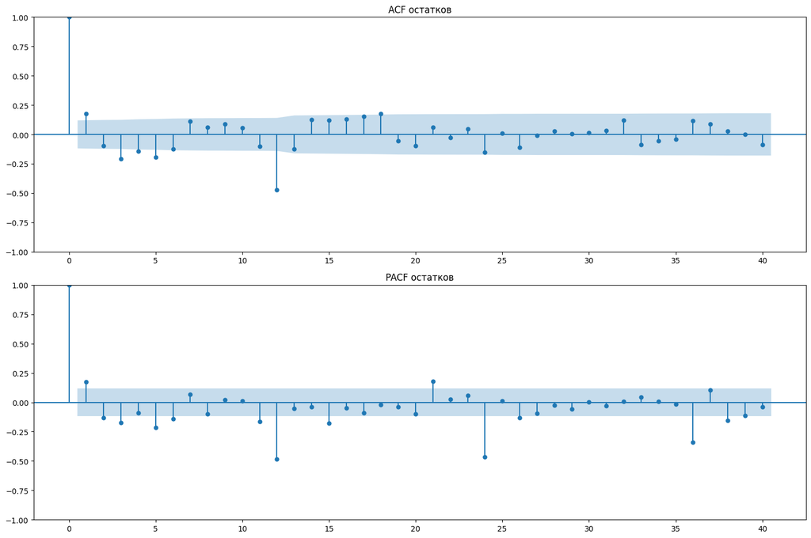

```python
fig, ax = plt.subplots(2, 1, figsize=(15, 10))

plot_acf(res.resid, lags=40, ax=ax[0])
ax[0].set_title('ACF остатков')

plot_pacf(res.resid, lags=40, ax=ax[1], method='ywm')
ax[1].set_title('PACF остатков')

plt.tight_layout()
plt.show()
```

#### Задание 3.2: Прогнозирование с помощью простых моделей (1 балл)

Давайте теперь построим свой первый бейзлайн. Для тренда возьмем модель Хольта, для сезонности — наивный сезонный метод (**реализуйте его сами!**).

Для этого метода используем преобразованный ряд с оптимальным $\lambda$ из предыдущего задания.

```python
class NaiveSeasonal:
    def __init__(self, seasonal_period: int):
        self.seasonal_period = seasonal_period
        self.last_season = None

    def fit(self, y: np.ndarray):
        # Запоминаем последний полный сезон
        self.last_season = y[-self.seasonal_period:]

    def predict(self, horizon: int) -> np.ndarray:
        # Повторяем сезонный паттерн необходимое количество раз
        repetitions = int(np.ceil(horizon / self.seasonal_period))
        seasonal_forecast = np.tile(self.last_season, repetitions)
        # Обрезаем до нужного горизонта
        return seasonal_forecast[:horizon]
```

Постройте прогноз на тестовую выборку.

```python
# Горизонт прогноза равен длине тестовой выборки
horizon = len(test)

# Прогноз тренда (Модель Хольта на компоненте тренда)
# res.trend - это компонент тренда из STL (на трансформированных данных)
trend_model = Holt(res.trend, initialization_method="estimated").fit()
trend_pred = trend_model.forecast(horizon)

# Прогноз сезонности (Наивный сезонный на компоненте сезонности)
# res.seasonal - это компонент сезонности из STL
seasonal_model = NaiveSeasonal(seasonal_period=12)
seasonal_model.fit(res.seasonal)
seasonal_pred = seasonal_model.predict(horizon)

# Суммируем прогнозы (в пространстве Box-Cox)
forecast_boxcox = trend_pred + seasonal_pred

# Обратная трансформация (возвращаемся к исходному масштабу)
final_forecast = inv_box_cox(forecast_boxcox, best_lam)

# Создаем Series для удобства
final_forecast_series = pd.Series(final_forecast, index=test.index)
```

Нарисуйте соответствующий график. На нем должна быть видна история из тренировочной выборки, тестовая выборка и прогноз. Не забудьте сделать обратное преобразование!

[figure not shown]

```python
plt.figure(figsize=(15, 6))
plt.plot(train['date'], train['y'], label='Train')
plt.plot(test['date'], test['y'], label='Test (Real)', color='green')

# Прогноз
plt.plot(test['date'], final_forecast_series, label='Forecast (Holt+Naive)', color='red', linestyle='--')
plt.title('Прогноз STL + Holt + NaiveSeasonal')
plt.xlabel('Дата')
plt.ylabel('Значение')
plt.legend()
plt.grid(True)
plt.show()
```

Оцените прогноз при помощи метрик MAE, MASE

```python
if 'metrics_storage' not in locals():
    metrics_storage = {}

def calculate_mase(forecast, insample, outsample, frequency):
    return np.mean(np.abs(forecast - outsample)) / np.mean(
        np.abs(insample[:-frequency] - insample[frequency:])
    )

mae_val = mean_absolute_error(test['y'], final_forecast)
mase_val = calculate_mase(final_forecast, train['y'].values, test['y'].values, 12)

model_name = "STL (Holt Trend + Naive Seas)"
metrics_storage[model_name] = {'MAE': mae_val, 'MASE': mase_val}

pd.DataFrame(metrics_storage).T
```

|  | MAE | MASE |
| --- | --- | --- |
| STL (Holt Trend + Naive Seas) | 3.317881 | 1.150156 |

**Здесь и в дальнейшем складывайте все метрики в словарь / датафрейм / еще куда-нибудь для удобства сравнения.**

### Задание 4: ETS модель (1.5 балла)

Исходя из экспериментов с бейзлайном, выберите подходящую [ETS](https://www.statsmodels.org/stable/generated/statsmodels.tsa.exponential_smoothing.ets.ETSModel.html) модель для ваших данных. Аргументируйте выбор.

**Обратите внимание, что моделировать нужно не преобразованный, а исходный ряд.**

Постройте прогноз на тестовую выборку.

Выбранная модель: ETS(M, A, M) — (Multiplicative Error, Additive Trend, Multiplicative Seasonality).

Аргументация:

- Сезонность (M): На графиках исходного ряда четко видно, что амплитуда колебаний растет вместе с ростом уровня ряда («эффект рупора»). Это прямой признак мультипликативной сезонности.
- Тренд (A): Тренд выглядит линейным (или близким к нему), поэтому выбираем аддитивный.
- Ошибка (M): Поскольку мы наблюдаем гетероскедастичность (дисперсия шума растет с уровнем), логично использовать мультипликативную ошибку.

```python
# Создаем копию, чтобы не ломать глобальные переменные
train_ets = train.copy().set_index('date')
# Явно указываем частоту (Month End)
train_ets.index = pd.DatetimeIndex(train_ets.index).to_period('M').to_timestamp('M')

ets_model = ETSModel(
    train_ets['y'],
    error='mul',
    trend='add',
    seasonal='mul',
    seasonal_periods=12
)
ets_fit = ets_model.fit()

# Горизонт прогноза
steps = len(test)
ets_pred = ets_fit.get_prediction(start=len(train), end=len(train) + steps - 1).predicted_mean

# Приводим индекс прогноза к формату теста для корректного отображения
ets_pred.index = test['date']
```

Нарисуйте соответствующий график. На нем должна быть видна история из тренировочной выборки, тестовая выборка и прогноз.

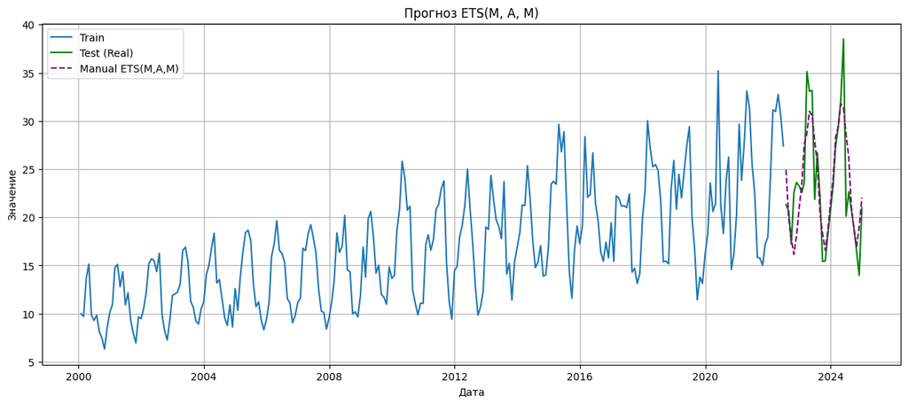

```python
plt.figure(figsize=(15, 6))
plt.plot(train['date'], train['y'], label='Train')
plt.plot(test['date'], test['y'], label='Test (Real)', color='green')
plt.plot(test['date'], ets_pred, label='Manual ETS(M,A,M)', color='purple', linestyle='--')

plt.title('Прогноз ETS(M, A, M)')
plt.xlabel('Дата')
plt.ylabel('Значение')
plt.legend()
plt.grid(True)
plt.show();
```

Оцените прогноз при помощи метрик MAE, MASE

```python
mae_ets = mean_absolute_error(test['y'], ets_pred)
mase_ets = calculate_mase(ets_pred, train['y'].values, test['y'].values, 12)

metrics_storage["Manual ETS(M,A,M)"] = {'MAE': mae_ets, 'MASE': mase_ets}
pd.DataFrame(metrics_storage).T
```

|  | MAE | MASE |
| --- | --- | --- |
| STL (Holt Trend + Naive Seas) | 3.317881 | 1.150156 |
| Manual ETS(M,A,M) | 2.579573 | 0.894219 |

Сравните вашу модель с тем, что выдает AutoETS из библиотеки [statsforecast](https://nixtlaverse.nixtla.io/statsforecast/index.html). Удалось ли вам побить AutoETS?

```python
# Подготовка данных в формат для statsforecast
train_sf = pd.DataFrame({
    'ds': train['date'],
    'y': train['y'],
    'unique_id': 'series_1'
})

#Запуск AutoETS
# season_length=12 (месячные данные)
sf = StatsForecast(
    models=[AutoETS(model='ZZZ', season_length=12)], # Z означает "подбери сам" для всех 3 компонент
    freq='ME' # Month End
)

sf.fit(train_sf)

# Прогноз
forecast_sf_df = sf.predict(h=len(test))
auto_ets_pred = forecast_sf_df['AutoETS'].values

# Метрики AutoETS
mae_auto = mean_absolute_error(test['y'], auto_ets_pred)
mase_auto = calculate_mase(auto_ets_pred, train['y'].values, test['y'].values, 12)

metrics_storage["AutoETS (StatsForecast)"] = {'MAE': mae_auto, 'MASE': mase_auto}
pd.DataFrame(metrics_storage).T
```

|  | MAE | MASE |
| --- | --- | --- |
| STL (Holt Trend + Naive Seas) | 3.317881 | 1.150156 |
| Manual ETS(M,A,M) | 2.579573 | 0.894219 |
| AutoETS (StatsForecast) | 2.584819 | 0.896037 |

Подсказка: скорее всего у вас не получилось:)

Если хотите побить AutoETS, попробуйте обратить внимание на вид остатков.